# Misregulation of H3K4me3

John Blischak

**Last updated:** 2015-10-22

**Code version:** 044491cd5df4302bbdcf97ec1313fa184fc31516

```r
library("knitr")
opts_chunk$set(fig.align = "center", fig.width = 10)
```

There is a clear trend in the metagene plot that H3K4me3 is misregulated across the gene body. The yeast with truncated Set1 have reduced H3K4me3 at the TSS and increased in the gene body. How many genes are affected in this way? To answer this question, I will calculate the difference between the mean rpm in bins 1-10 at the beginning of the gene body compared to bins 31-40, where the largest difference is seen the the metagene plot. For each gene, I will test if this difference changes between yeast with the different versions of Set1.

## Setup

```r
library("tidyr")
library("dplyr")
library("ggplot2")
library("cowplot")
theme_set(theme_bw(base_size = 12))
```

Read in the reads per million (rpm) data with the input subtracted.

```r
anno <- read.table("../../data/yeast/annotation.txt", header = TRUE, sep = "\t",
                   stringsAsFactors = FALSE)
counts_cpm_std <- read.table("../../data/yeast/counts-cpm-std.txt", header = TRUE, sep = "\t",
                   stringsAsFactors = FALSE)
stopifnot(grep("H3K4me3", anno$sample, value = TRUE) ==
          grep("H3K4me3", colnames(counts_cpm_std), value = TRUE))
```

Calculate the difference.

```r
counts_long <- gather(counts_cpm_std, key = "sample", value = "cpm",
                      H3K4me3.aa762_1080.r1:H3K4me3.full_length.r2)
difference <- counts_long %>%
  group_by(sample, gene) %>%
  summarize(mean_tss = mean(cpm[bin %in% 1:10]),
            mean_body = mean(cpm[bin %in% 31:40]),
            difference = mean_tss - mean_body)
difference <- separate(difference, col = sample, into = c("ip", "set1", "replicate"),
                  sep = "\\.")
```

Remove genes where the difference is static across the samples (t-test throws an error).

```r
static_genes <- difference %>% group_by(gene) %>%
  summarize(variance = var(difference)) %>%
  filter(variance < 0.1) %>%
  select(gene) %>%
  unlist
difference <- difference %>% filter(!(gene %in% static_genes))
```

How much variation is there in these metrics?

```
## stat_bin: binwidth defaulted to range/30. Use 'binwidth = x' to adjust this.
```

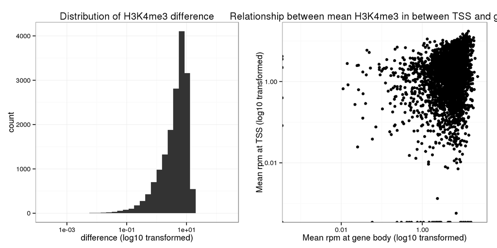

```r
difference_hist <- ggplot(difference, aes(x = difference)) +
  geom_histogram() +
  scale_x_log10() +
  labs(title = "Distribution of H3K4me3 difference",
       x = "difference (log10 transformed)")
compare_mean_plot <- ggplot(difference, aes(x = mean_tss, y = mean_body)) +
  geom_point() +
  scale_x_log10() + scale_y_log10() +
    labs(title = "Relationship between mean H3K4me3 in between TSS and gene body",
       x = "Mean rpm at gene body (log10 transformed)",
       y = "Mean rpm at TSS (log10 transformed)")
plot_grid(difference_hist, compare_mean_plot)
```

Peform the test.

```r
result <- difference %>% group_by(gene) %>%
  # filter(var(difference) > 1) %>%
  summarize(tstat = t.test(difference[set1 == "full_length"],
                           difference[set1 == "aa762_1080"])$statistic,
            pval = t.test(difference[set1 == "full_length"],
                           difference[set1 == "aa762_1080"])$p.value)
result$facet <- cut(result$tstat, breaks = quantile(result$tstat),
                    include.lowest = TRUE)
```

There is a clear enrichment of signal in the p-value distribution.

```
## stat_bin: binwidth defaulted to range/30. Use 'binwidth = x' to adjust this.
```

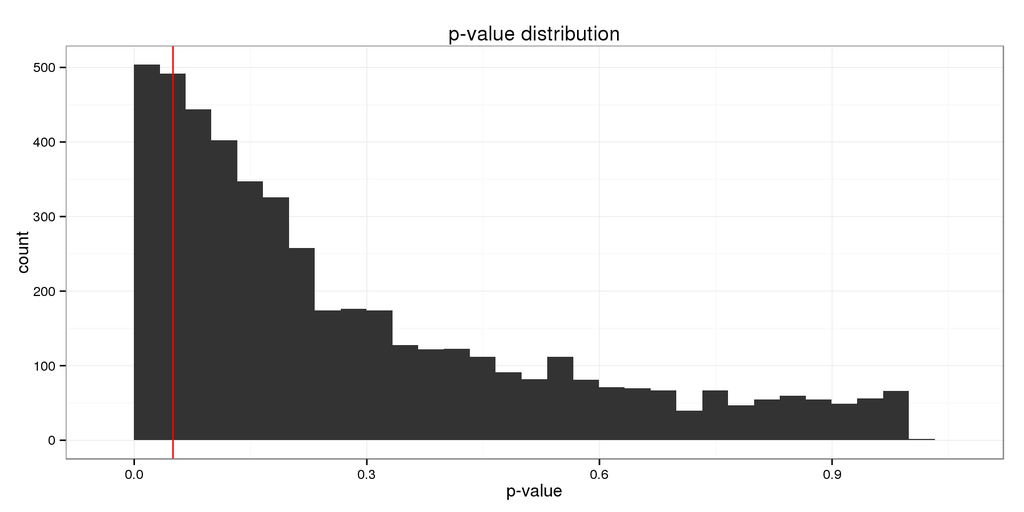

```r
ggplot(result, aes(x = pval)) +
  geom_histogram() +
  labs(title = "p-value distribution",
       x = "p-value") +
  geom_vline(x = 0.05, col = "red")
```

```r
n_sig <- sum(result$pval < .05)
n_sig_fdr <- sum(p.adjust(result$pval) < .05)
```

758 of the total 4853 genes tested had a significant difference in the H3K4me3 distribution. However, after FDR correction for multiple testing, 0 genes were significant. This is likely due to the small sample size.

## Plot metagene split by differences in H3K4me3 misregulation

Using the t-statistic from the above test, plot the distribution of H3K4me3 for genes with varying levels of evidence for misregulation.

```r
counts_long <- merge(counts_long, result, by = "gene")

metagene <- counts_long %>%
  group_by(sample, bin, facet) %>%
  summarize(mean = mean(cpm),
            sem = sd(cpm) / sqrt(n()))
metagene$bin <- as.numeric(metagene$bin)
metagene$sample <- factor(metagene$sample,
                          levels = c("H3K4me3.full_length.r1",
                                     "H3K4me3.full_length.r2",
                                     "H3K4me3.aa762_1080.r1",
                                     "H3K4me3.aa762_1080.r2"),
                          labels = c("H3K4me3 full length Rep 1",
                                     "H3K4me3 full length Rep 2",
                                     "H3K4me3 aa762-1080 Rep 1",
                                     "H3K4me3 aa762-1080 Rep 2"))
```

Plot the metagene result.

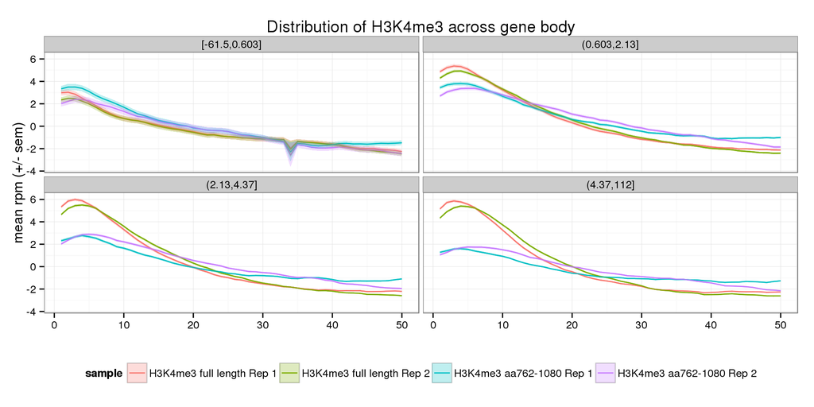

```r
ggplot(metagene, aes(x = bin, y = mean)) +
  geom_line(aes(color = sample)) +
  geom_ribbon(aes(ymin = mean - sem, ymax = mean + sem, fill = sample),
              alpha = 0.25) +
  labs(x = "", y = "mean rpm (+/- sem)",
       title = "Distribution of H3K4me3 across gene body") +
  facet_wrap(~facet) +
  theme(legend.position = "bottom")
```

Each quantile contains ~1213 genes.

```r
table(result$facet)
```

```
##
## [-61.5,0.603]  (0.603,2.13]   (2.13,4.37]    (4.37,112]
##          1214          1213          1213          1213
```

## TFIID versus SAGA regulation

[Soares et al., 2014](http://www.ncbi.nlm.nih.gov/pubmed/24613354) studied the effect of Set1 truncations on H3K4me3. They used results from [Huisinga & Pugh, 2004](http://www.ncbi.nlm.nih.gov/pubmed/14992726) to show the differences between those genes that are regulated by TFIID versus SAGA. From their paper:

> Given the differential responses of PMA1 and RPS13 to reduced Set1 activity, we sought to identify features that distin- guish these genes. Huisinga and Pugh (2004) sorted genes into two classes based on sensitivity to TFIID or SAGA mutants. TFIID function predominates at approximately 90% of genes, mostly constitutively expressed, and SAGA is important for expression of the remaining, often highly regulated, 10%. PMA1 is classified as SAGA dependent, whereas RPS13 is TFIID responsive.

They observed higher H3K4me3 at SAGA-regulated genes compared to TFIID genes. Furthermore, they observed that H3K4me3 was affected much more at SAGA-regulated genes in yeast with truncated Set1. I wanted to see if I observed similar patterns.

```r
huisinga2004 <- read.table("../../data/yeast/huisinga-2004-table-s02.txt", header = TRUE,
                           sep = "\t", stringsAsFactors = FALSE)
head(huisinga2004)
```

```
##   SAGA.TFIID.group Gene.ID Common.Name
## 1  TFIID-dominated YAL001C        TFC3
## 2  TFIID-dominated YAL002W        VPS8
## 3  TFIID-dominated YAL003W        EFB1
## 4  TFIID-dominated YAL004W
## 5  TFIID-dominated YAL005C        SSA1
## 6  TFIID-dominated YAL007C        ERP2
```

Merge with the test results.

```r
result <- merge(result, huisinga2004, by.x = "gene", by.y = "Gene.ID")
# Remove genes with empty cells from Table S02
result <- result %>% filter(SAGA.TFIID.group != "")
```

There are 4535 in this data set that were also annotated by Huisinga & Pugh, 2004.

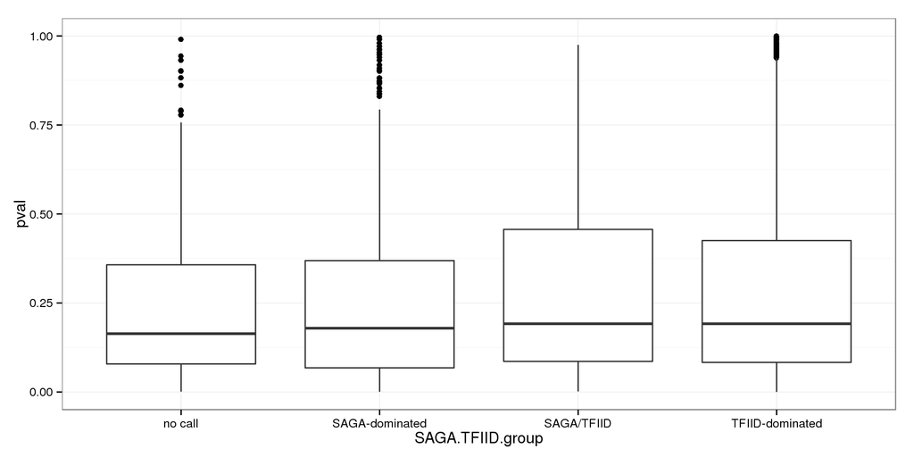

```r
ggplot(result, aes(x = SAGA.TFIID.group, y = pval)) + geom_boxplot()
```

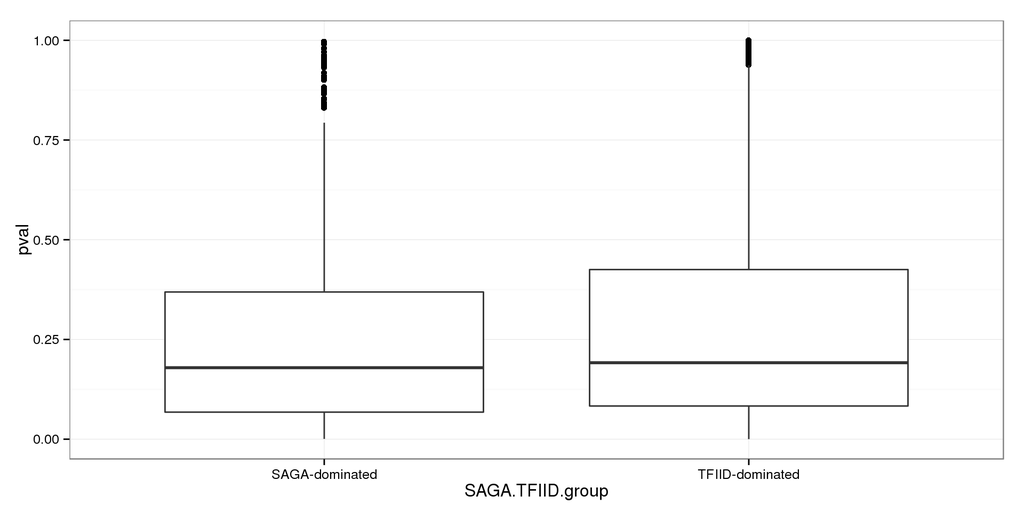

```r
ggplot(result[result$SAGA.TFIID.group %in% c("SAGA-dominated", "TFIID-dominated"), ],
       aes(x = SAGA.TFIID.group, y = pval)) + geom_boxplot()
```

```r
# Performs one or two sample Kolmogorov-Smirnov tests
ks.test(result$pval[result$SAGA.TFIID.group == "SAGA-dominated"],
        result$pval[result$SAGA.TFIID.group == "TFIID-dominated"])
```

```
##
##  Two-sample Kolmogorov-Smirnov test
##
## data:  result$pval[result$SAGA.TFIID.group == "SAGA-dominated"] and result$pval[result$SAGA.TFIID.group == "TFIID-dominated"]
## D = 0.057499, p-value = 0.1643
## alternative hypothesis: two-sided
```

Prepare for plotting.

```r
counts_long <- merge(counts_long, huisinga2004, by.x = "gene", by.y = "Gene.ID")
# Remove genes with empty cells from Table S02
counts_long <- counts_long %>% filter(SAGA.TFIID.group != "")
metagene_saga <- counts_long %>%
  group_by(sample, bin, SAGA.TFIID.group) %>%
  summarize(mean = mean(cpm),
            sem = sd(cpm) / sqrt(n()))
metagene_saga$bin <- as.numeric(metagene_saga$bin)
metagene_saga$sample <- factor(metagene_saga$sample,
                          levels = c("H3K4me3.full_length.r1",
                                     "H3K4me3.full_length.r2",
                                     "H3K4me3.aa762_1080.r1",
                                     "H3K4me3.aa762_1080.r2"),
                          labels = c("H3K4me3 full length Rep 1",
                                     "H3K4me3 full length Rep 2",
                                     "H3K4me3 aa762-1080 Rep 1",
                                     "H3K4me3 aa762-1080 Rep 2"))
```

Plot the metagene result.

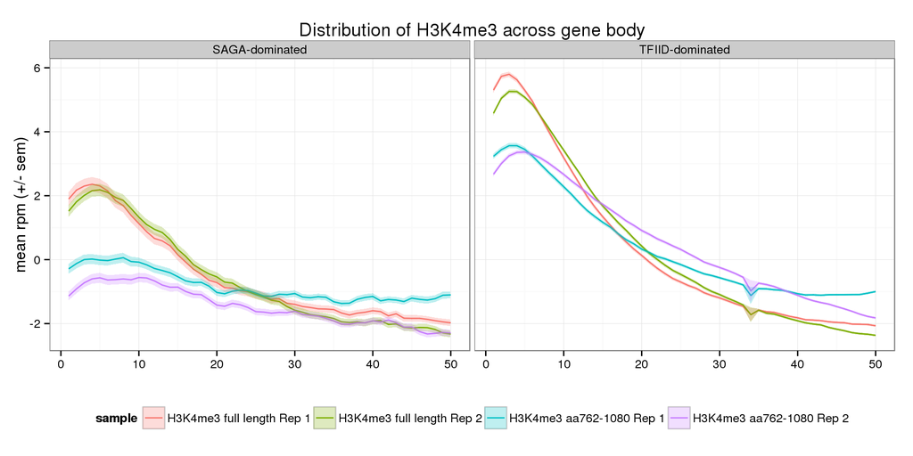

```r
ggplot(metagene_saga[metagene_saga$SAGA.TFIID.group %in% c("SAGA-dominated", "TFIID-dominated"), ],
       aes(x = bin, y = mean)) +
  geom_line(aes(color = sample)) +
  geom_ribbon(aes(ymin = mean - sem, ymax = mean + sem, fill = sample),
              alpha = 0.25) +
  labs(x = "", y = "mean rpm (+/- sem)",
       title = "Distribution of H3K4me3 across gene body") +
  facet_wrap(~SAGA.TFIID.group) +
  theme(legend.position = "bottom")
```

Strangely, I observe more H3K4me3 enrichment at TFIID-regulated genes compared to SAGA-regulated genes. I’m not sure what is going on here.

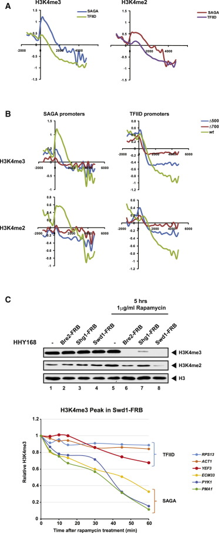